# Latihan 4 MPDW

Lutfi Syahreza Lubis

2023-09-21

## White Noise

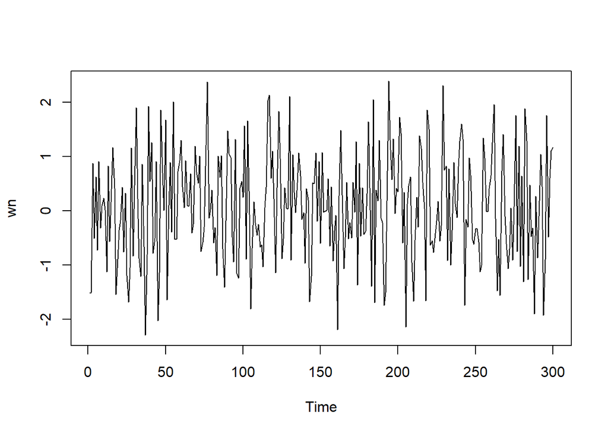

```r
wn <- rnorm(300)
ts.plot(wn)
```

## Proses MA

```r
set.seed(003)
ma <- wn[c(1,2)]
```

```r
for(i in 3:300){
   ma[i] <- wn[i] + 0.4 * wn[i - 1] + 0.6 * wn[i - 2]
}
ma
```

```
##   [1] -1.5114177107 -1.5014924756 -0.6316680013 -1.0566002842  0.9530133572
##   [6] -0.7723288217  1.0020979829 -0.3825444398  0.5194247560  0.0881436273
##  [11]  0.1753065766 -0.9720044038  0.3919781804 -0.9041124971  0.6773968577
##  [16]  0.9934533642  1.1328813153 -0.6707618116 -1.2474458923 -1.6371529229
##  [21] -0.8464504592  0.1490866402 -0.6880615768  0.2854255682 -1.5116069278
##  [26] -1.9618490378 -2.4362269998 -0.2700869785 -0.9975552747  0.8366818652
##  [31]  1.5939522201  1.2729206451  0.3619215291 -1.4196150071 -0.1453453124
##  [36] -1.0368402454 -2.0363736267 -2.1157230988  0.2309566651  0.8360570981
##  [41]  2.6408921656  0.0588559453 -0.0543485477  0.2462278886 -1.9557375962
##  [46] -1.3990508003  0.1959405909  0.7686625174  1.4107669888  2.1053989207
##  [51] -0.9648217503  0.4547073794 -0.0490856581  0.0350167118  2.3920771996
##  [56]  0.0546945953  0.4805170110  0.2112466708  0.9092513080  2.1150010840
##  [61]  1.5218606187  1.0244607492  1.2171838282  0.5119496219  0.6817477852
##  [66]  0.7810329499 -0.0777121234  0.0023525466  0.8558643911  1.0461471272
##  [71]  1.5162595888  1.6490752298 -0.0320422476 -0.2694285839 -0.9797854628
```

[output cut: 45 more lines]

```r
ma2 <- arima.sim(list(order=c(0,0,2), ma=c(0.4,0.6)), n=300)
ma2
```

```
## Time Series:
## Start = 1
## End = 300
## Frequency = 1
##   [1] -0.43538212 -1.22413203 -0.10979700 -0.58284206  0.21493701  1.16885167
##   [7] -0.72096269  1.44979188 -0.96914856 -0.66870998 -1.61571488 -0.71262217
##  [13] -0.17670844 -0.09524673 -0.98485248 -1.21404360  0.39320610  0.30059137
##  [19]  0.23602910 -1.05380726 -0.92773871 -2.31334655 -1.27328195 -1.93473961
##  [25]  0.57351365  1.03166984  1.02911784 -0.55837341  0.40266473  0.52995096
##  [31]  1.60879819  1.53865048  0.37910035  1.00656495  1.37128642  0.98170452
##  [37] -0.18376817  0.42499893  0.51644110  0.48039636  2.04660372 -0.30131765
##  [43]  1.04993114 -2.60278221 -0.85930308 -0.29325776 -0.10052315 -0.40286571
##  [49]  0.09384479 -1.05820513  0.37941210 -2.11609421 -1.94607955 -2.06047951
##  [55] -2.06376685  0.67581565  0.84101913  0.39912627  0.80993535  0.67651818
##  [61]  0.96767666  1.00539919  1.46889634  0.20006850  0.09343414  0.49907309
```

[output cut: 39 more lines]

## Karakteristik MA(2)

### Plot Time Series

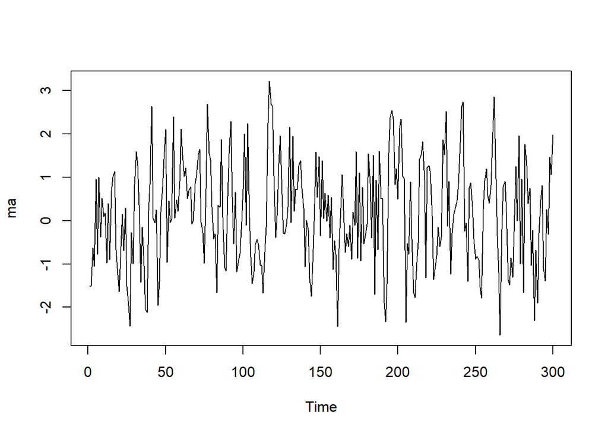

```r
ts.plot(ma)
```

Berdasarkan plot time series, terlihat bahwa data MA(2) yang dibangkitkan stasioner dalam rataan

### Plot ACF

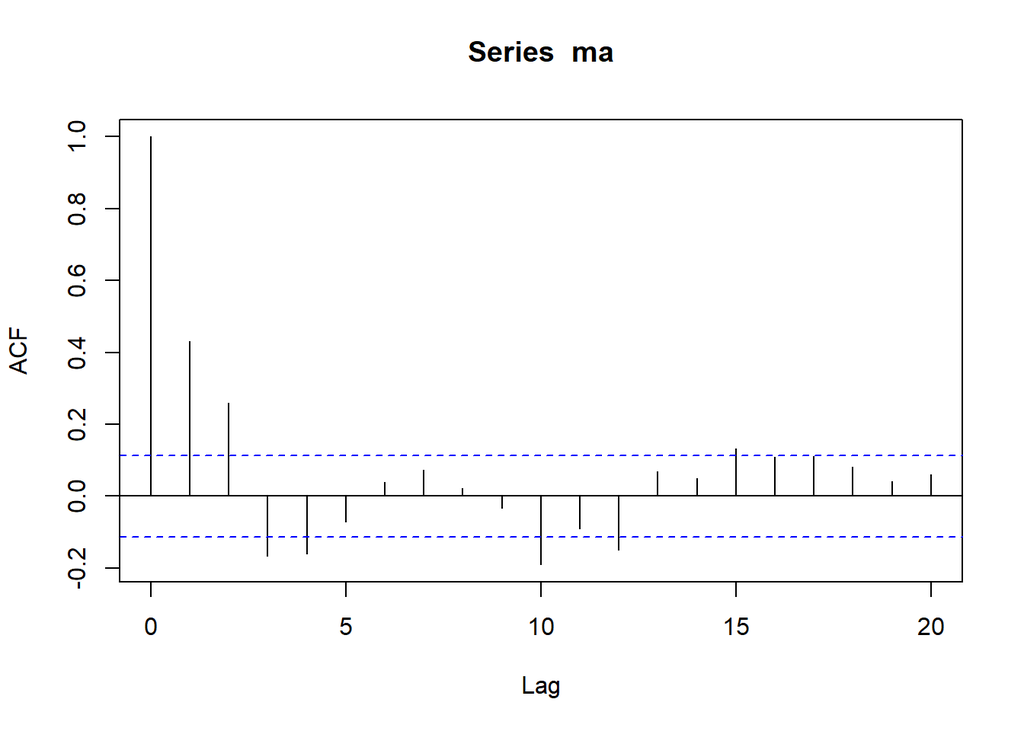

```r
acf(ma,lag.max = 20)
```

### Plot PACF

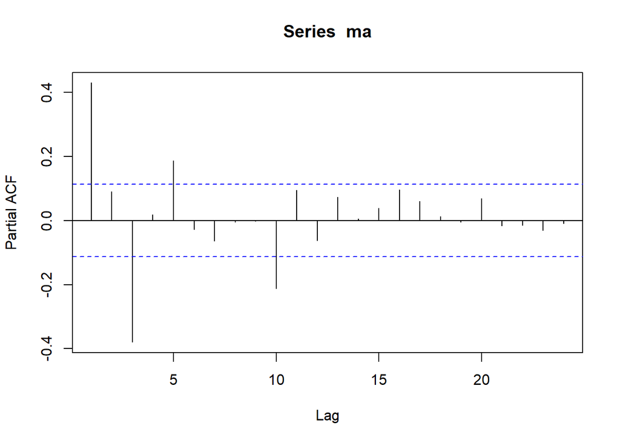

```r
pacf(ma)
```

Berdasarkan plot PACF tersebut, terlihat bahwa plot PACF cenderung *tails off* dan membentuk gelombang sinus

### Plot EACF

```r
TSA::eacf(ma)
```

```
## AR/MA
##   0 1 2 3 4 5 6 7 8 9 10 11 12 13
## 0 x x x x o o o o o x o  x  o  o
## 1 x x x o o o o o o x o  x  x  o
## 2 x x x x o o o o o x o  x  o  o
## 3 o x o o o o o o o x o  x  x  o
## 4 o x x o o o o o o o o  o  x  o
## 5 x x x x o o o o o o o  o  x  o
## 6 x x x o o o x x o o o  o  x  o
## 7 o o o o o o x x o o o  o  x  o
```

### Scatterplot Antar Lag

#### Korelasi antara $Y_t$ dengan $Y_{t-1}$

```r
#Yt
yt_ma <- ma[-1]
yt_ma
```

```
##   [1] -1.5014924756 -0.6316680013 -1.0566002842  0.9530133572 -0.7723288217
##   [6]  1.0020979829 -0.3825444398  0.5194247560  0.0881436273  0.1753065766
##  [11] -0.9720044038  0.3919781804 -0.9041124971  0.6773968577  0.9934533642
##  [16]  1.1328813153 -0.6707618116 -1.2474458923 -1.6371529229 -0.8464504592
##  [21]  0.1490866402 -0.6880615768  0.2854255682 -1.5116069278 -1.9618490378
##  [26] -2.4362269998 -0.2700869785 -0.9975552747  0.8366818652  1.5939522201
##  [31]  1.2729206451  0.3619215291 -1.4196150071 -0.1453453124 -1.0368402454
##  [36] -2.0363736267 -2.1157230988  0.2309566651  0.8360570981  2.6408921656
##  [41]  0.0588559453 -0.0543485477  0.2462278886 -1.9557375962 -1.3990508003
##  [46]  0.1959405909  0.7686625174  1.4107669888  2.1053989207 -0.9648217503
##  [51]  0.4547073794 -0.0490856581  0.0350167118  2.3920771996  0.0546945953
##  [56]  0.4805170110  0.2112466708  0.9092513080  2.1150010840  1.5218606187
##  [61]  1.0244607492  1.2171838282  0.5119496219  0.6817477852  0.7810329499
##  [66] -0.0777121234  0.0023525466  0.8558643911  1.0461471272  1.5162595888
##  [71]  1.6490752298 -0.0320422476 -0.2694285839 -0.9797854628  0.7412705766
```

[output cut: 45 more lines]

```r
#Yt-1
yt_1_ma <- ma[-300]
yt_1_ma
```

```
##   [1] -1.5114177107 -1.5014924756 -0.6316680013 -1.0566002842  0.9530133572
##   [6] -0.7723288217  1.0020979829 -0.3825444398  0.5194247560  0.0881436273
##  [11]  0.1753065766 -0.9720044038  0.3919781804 -0.9041124971  0.6773968577
##  [16]  0.9934533642  1.1328813153 -0.6707618116 -1.2474458923 -1.6371529229
##  [21] -0.8464504592  0.1490866402 -0.6880615768  0.2854255682 -1.5116069278
##  [26] -1.9618490378 -2.4362269998 -0.2700869785 -0.9975552747  0.8366818652
##  [31]  1.5939522201  1.2729206451  0.3619215291 -1.4196150071 -0.1453453124
##  [36] -1.0368402454 -2.0363736267 -2.1157230988  0.2309566651  0.8360570981
##  [41]  2.6408921656  0.0588559453 -0.0543485477  0.2462278886 -1.9557375962
##  [46] -1.3990508003  0.1959405909  0.7686625174  1.4107669888  2.1053989207
##  [51] -0.9648217503  0.4547073794 -0.0490856581  0.0350167118  2.3920771996
##  [56]  0.0546945953  0.4805170110  0.2112466708  0.9092513080  2.1150010840
##  [61]  1.5218606187  1.0244607492  1.2171838282  0.5119496219  0.6817477852
##  [66]  0.7810329499 -0.0777121234  0.0023525466  0.8558643911  1.0461471272
##  [71]  1.5162595888  1.6490752298 -0.0320422476 -0.2694285839 -0.9797854628
```

[output cut: 45 more lines]

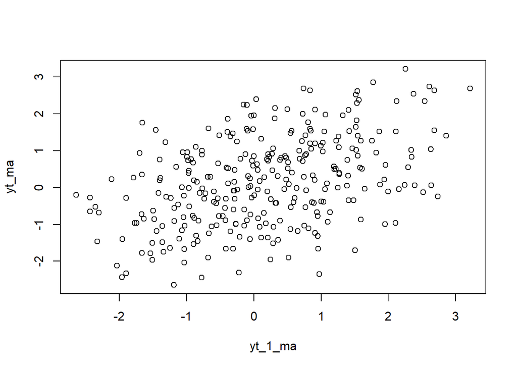

```r
plot(y=yt_ma,x=yt_1_ma)
```

Berdasarkan scatterplot tersebut, terlihat bahwa terdapat hubungan positif antara $Y_t$ dengan $Y_{t-1}$.

```r
cor(yt_ma,yt_1_ma)
```

```
## [1] 0.4334181
```

#### Korelasi antara $Y_t$ dengan $Y_{t-2}$

```r
#Yt
yt_ma2 <- ma[-c(1,2)]
yt_ma2
```

```
##   [1] -0.6316680013 -1.0566002842  0.9530133572 -0.7723288217  1.0020979829
##   [6] -0.3825444398  0.5194247560  0.0881436273  0.1753065766 -0.9720044038
##  [11]  0.3919781804 -0.9041124971  0.6773968577  0.9934533642  1.1328813153
##  [16] -0.6707618116 -1.2474458923 -1.6371529229 -0.8464504592  0.1490866402
##  [21] -0.6880615768  0.2854255682 -1.5116069278 -1.9618490378 -2.4362269998
##  [26] -0.2700869785 -0.9975552747  0.8366818652  1.5939522201  1.2729206451
##  [31]  0.3619215291 -1.4196150071 -0.1453453124 -1.0368402454 -2.0363736267
##  [36] -2.1157230988  0.2309566651  0.8360570981  2.6408921656  0.0588559453
##  [41] -0.0543485477  0.2462278886 -1.9557375962 -1.3990508003  0.1959405909
##  [46]  0.7686625174  1.4107669888  2.1053989207 -0.9648217503  0.4547073794
##  [51] -0.0490856581  0.0350167118  2.3920771996  0.0546945953  0.4805170110
##  [56]  0.2112466708  0.9092513080  2.1150010840  1.5218606187  1.0244607492
##  [61]  1.2171838282  0.5119496219  0.6817477852  0.7810329499 -0.0777121234
##  [66]  0.0023525466  0.8558643911  1.0461471272  1.5162595888  1.6490752298
##  [71] -0.0320422476 -0.2694285839 -0.9797854628  0.7412705766  2.6841370830
```

[output cut: 45 more lines]

```r
#Yt-2
yt_2_ma <- ma[-c(299,300)]
yt_2_ma
```

```
##   [1] -1.5114177107 -1.5014924756 -0.6316680013 -1.0566002842  0.9530133572
##   [6] -0.7723288217  1.0020979829 -0.3825444398  0.5194247560  0.0881436273
##  [11]  0.1753065766 -0.9720044038  0.3919781804 -0.9041124971  0.6773968577
##  [16]  0.9934533642  1.1328813153 -0.6707618116 -1.2474458923 -1.6371529229
##  [21] -0.8464504592  0.1490866402 -0.6880615768  0.2854255682 -1.5116069278
##  [26] -1.9618490378 -2.4362269998 -0.2700869785 -0.9975552747  0.8366818652
##  [31]  1.5939522201  1.2729206451  0.3619215291 -1.4196150071 -0.1453453124
##  [36] -1.0368402454 -2.0363736267 -2.1157230988  0.2309566651  0.8360570981
##  [41]  2.6408921656  0.0588559453 -0.0543485477  0.2462278886 -1.9557375962
##  [46] -1.3990508003  0.1959405909  0.7686625174  1.4107669888  2.1053989207
##  [51] -0.9648217503  0.4547073794 -0.0490856581  0.0350167118  2.3920771996
##  [56]  0.0546945953  0.4805170110  0.2112466708  0.9092513080  2.1150010840
##  [61]  1.5218606187  1.0244607492  1.2171838282  0.5119496219  0.6817477852
##  [66]  0.7810329499 -0.0777121234  0.0023525466  0.8558643911  1.0461471272
##  [71]  1.5162595888  1.6490752298 -0.0320422476 -0.2694285839 -0.9797854628
```

[output cut: 45 more lines]

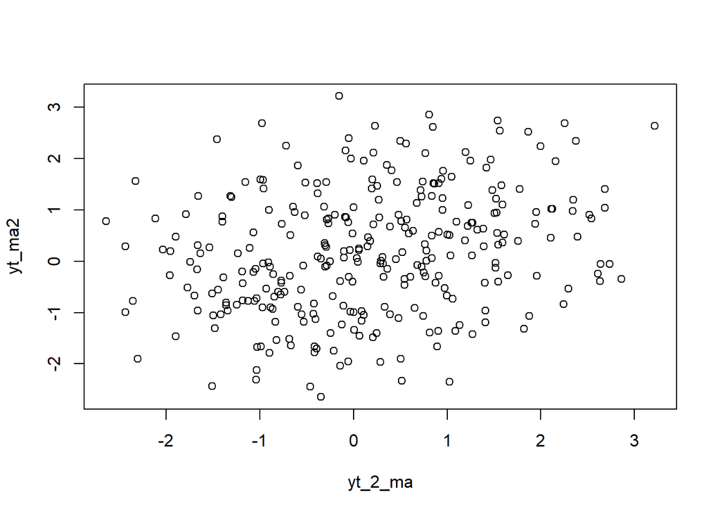

```r
plot(y=yt_ma2,x=yt_2_ma)
```

Berdasarkan scatterplot tersebut, terlihat bahwa terdapat hubungan positif antara $Y_t$ dengan $Y_{t-2}$.

```r
cor(yt_ma2,yt_2_ma)
```

```
## [1] 0.2618566
```

#### Korelasi antara $Y_t$ dengan $Y_{t-3}$

```r
#Yt
yt_ma3 <- ma[-c(1,2,3)]
yt_ma3
```

```
##   [1] -1.0566002842  0.9530133572 -0.7723288217  1.0020979829 -0.3825444398
##   [6]  0.5194247560  0.0881436273  0.1753065766 -0.9720044038  0.3919781804
##  [11] -0.9041124971  0.6773968577  0.9934533642  1.1328813153 -0.6707618116
##  [16] -1.2474458923 -1.6371529229 -0.8464504592  0.1490866402 -0.6880615768
##  [21]  0.2854255682 -1.5116069278 -1.9618490378 -2.4362269998 -0.2700869785
##  [26] -0.9975552747  0.8366818652  1.5939522201  1.2729206451  0.3619215291
##  [31] -1.4196150071 -0.1453453124 -1.0368402454 -2.0363736267 -2.1157230988
##  [36]  0.2309566651  0.8360570981  2.6408921656  0.0588559453 -0.0543485477
##  [41]  0.2462278886 -1.9557375962 -1.3990508003  0.1959405909  0.7686625174
##  [46]  1.4107669888  2.1053989207 -0.9648217503  0.4547073794 -0.0490856581
##  [51]  0.0350167118  2.3920771996  0.0546945953  0.4805170110  0.2112466708
##  [56]  0.9092513080  2.1150010840  1.5218606187  1.0244607492  1.2171838282
##  [61]  0.5119496219  0.6817477852  0.7810329499 -0.0777121234  0.0023525466
##  [66]  0.8558643911  1.0461471272  1.5162595888  1.6490752298 -0.0320422476
##  [71] -0.2694285839 -0.9797854628  0.7412705766  2.6841370830  1.5465541454
```

[output cut: 45 more lines]

```r
#Yt-2
yt_3_ma <- ma[-c(298,299,300)]
yt_3_ma
```

```
##   [1] -1.5114177107 -1.5014924756 -0.6316680013 -1.0566002842  0.9530133572
##   [6] -0.7723288217  1.0020979829 -0.3825444398  0.5194247560  0.0881436273
##  [11]  0.1753065766 -0.9720044038  0.3919781804 -0.9041124971  0.6773968577
##  [16]  0.9934533642  1.1328813153 -0.6707618116 -1.2474458923 -1.6371529229
##  [21] -0.8464504592  0.1490866402 -0.6880615768  0.2854255682 -1.5116069278
##  [26] -1.9618490378 -2.4362269998 -0.2700869785 -0.9975552747  0.8366818652
##  [31]  1.5939522201  1.2729206451  0.3619215291 -1.4196150071 -0.1453453124
##  [36] -1.0368402454 -2.0363736267 -2.1157230988  0.2309566651  0.8360570981
##  [41]  2.6408921656  0.0588559453 -0.0543485477  0.2462278886 -1.9557375962
##  [46] -1.3990508003  0.1959405909  0.7686625174  1.4107669888  2.1053989207
##  [51] -0.9648217503  0.4547073794 -0.0490856581  0.0350167118  2.3920771996
##  [56]  0.0546945953  0.4805170110  0.2112466708  0.9092513080  2.1150010840
##  [61]  1.5218606187  1.0244607492  1.2171838282  0.5119496219  0.6817477852
##  [66]  0.7810329499 -0.0777121234  0.0023525466  0.8558643911  1.0461471272
##  [71]  1.5162595888  1.6490752298 -0.0320422476 -0.2694285839 -0.9797854628
```

[output cut: 45 more lines]

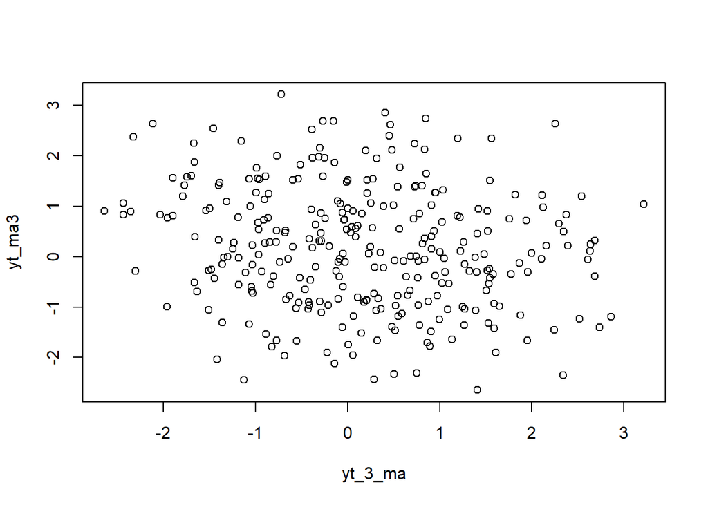

```r
plot(y=yt_ma3,x=yt_3_ma)
```

Berdasarkan scatterplot tersebut, terlihat bahwa cenderung tidak terdapat hubungan antara $Y_t$ dengan $Y_{t-3}$.

```r
cor(yt_ma3,yt_3_ma)
```

```
## [1] -0.1686563
```

## Pembangkitan Proses AR

```r
set.seed(003)
```

```r
n<-length(wn)
n
```

```
## [1] 300
```

```r
ar <- c(1:n)
for (i in 3:n) {ar[i]<-wn[i]+0.5*ar[i-1]+0.2*ar[i-2]}
ar
```

```
##   [1]  1.000000000  2.000000000  2.075779615  0.931873163  1.511044750
##   [6]  0.221197275  1.325214116  0.391759302  0.558938197  0.595810624
##  [11]  0.430994228 -0.788659475  0.520394008 -0.459066120  0.279440151
##  [16]  1.216321189  1.086627559 -0.754263971 -1.044462931 -1.031869407
##  [21] -0.896969815 -0.221644050 -1.048277945 -0.239746275 -1.517787083
##  [26] -2.490621396 -2.598628661 -0.637354210 -1.670135544 -0.489214306
##  [31]  1.325027859  0.792132280 -0.210188516 -1.154255445  0.241280456
##  [36] -0.766676873 -2.625137096 -2.271725514  0.266427976  0.227491677
##  [41]  1.432083591 -0.014798462 -0.223826918  0.798295655 -1.664916032
##  [46] -1.812031579  0.624213758  0.656617596  0.463224073  2.040155248
##  [51] -0.529030703  0.248592519  0.912425617  0.120327732  2.252606322
##  [56]  0.632442518  0.248455611  0.980033459  1.468204447  2.236121071
##  [61]  1.854059224  1.438164162  2.016098940  1.398803717  1.187397857
##  [66]  1.558709289  0.614156519  0.371093973  1.504939757  1.542846900
##  [71]  1.584270819  2.115341316  0.629512313  0.157618924 -0.095983835
```

[output cut: 45 more lines]

### Cara lain

```r
ar2 <- arima.sim(list(order=c(2,0,0), ar=c(0.5,0.2)), n=300)
ar2
```

```
## Time Series:
## Start = 1
## End = 300
## Frequency = 1
##   [1] -2.137814615 -0.277945809  0.445531298  0.095098013 -1.000127032
##   [6]  0.419580815  0.861535448  1.242399061  1.530008766  0.661354578
##  [11]  1.342194556  2.103726182  1.358554017  0.120738475  1.125841272
##  [16]  1.373575203  0.601492725  2.274346248  0.462877961  1.034745946
##  [21] -1.655452508 -0.782982344  0.408283318 -0.408000786 -1.021510045
##  [26]  0.134483722 -0.946501050 -0.179268665 -2.016198253 -2.455377995
##  [31] -2.084479875 -2.568806812 -0.339156488  0.234117131 -0.735914893
##  [36]  0.252384153  0.897205305  0.755366756  0.909090995  1.779956206
##  [41]  0.590949927  0.232636482  1.189621030 -0.647668800  0.100287239
##  [46] -0.110715642  0.431796937  1.217953014  0.962694347  0.956763879
##  [51]  1.418513273  2.117677923  1.725899961  0.298432744  0.337543454
```

[output cut: 49 more lines]

## Karakteristik AR(2)

### Plot Time Series

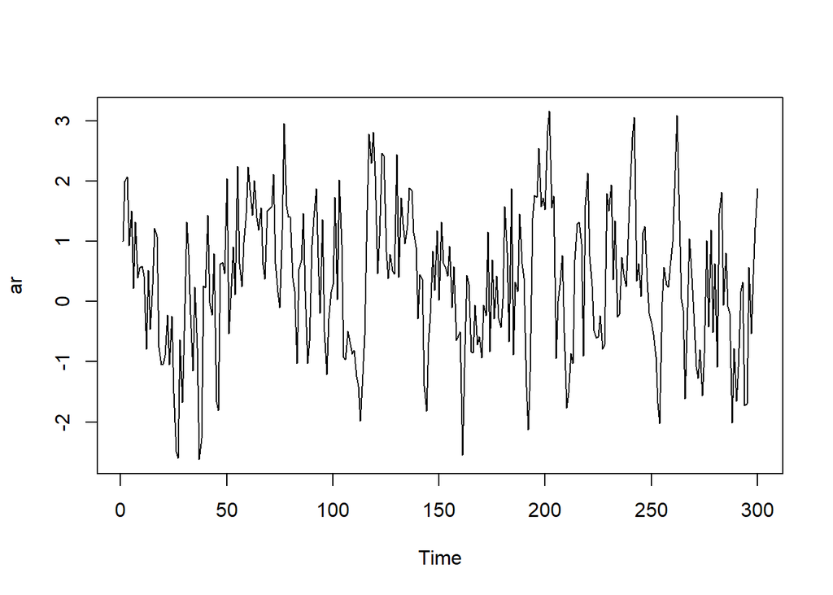

```r
ts.plot(ar)
```

Berdasarkan plot time series tersebut terlihat bahwa data cenderung stasioner pada rataan.

### Plot ACF

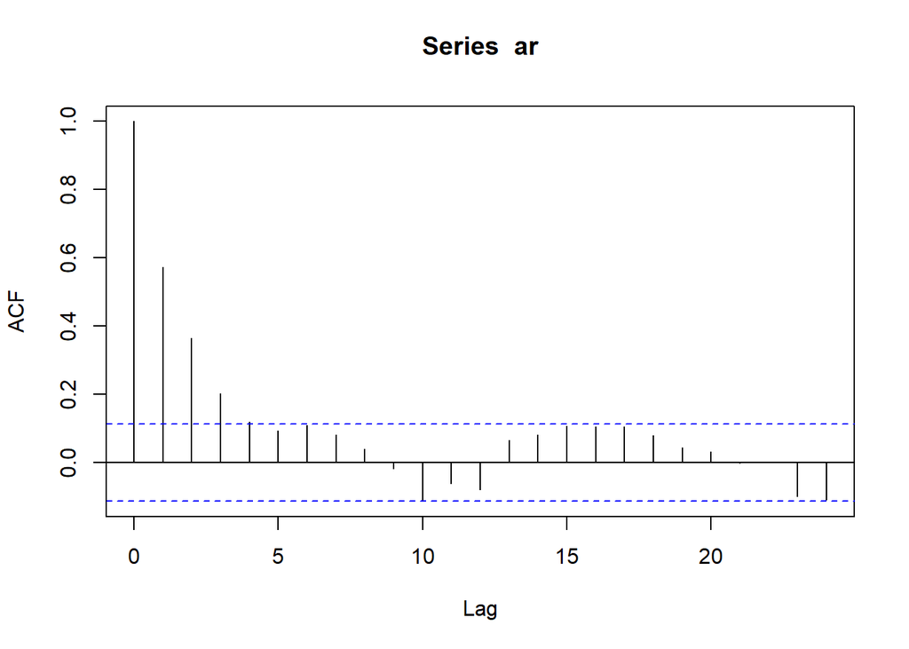

```r
acf(ar)
```

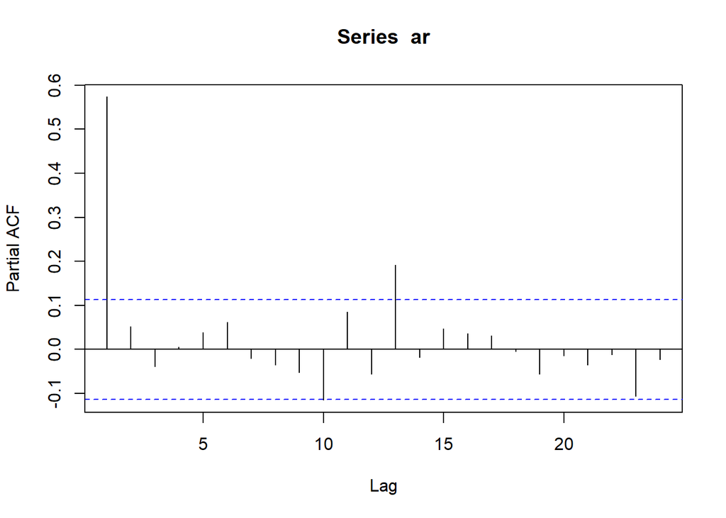

```r
pacf(ar)
```

Berdasarkan plot PACF tersebut, terlihat bahwa plot PACF *cuts off* pada lag pertama

### Plot EACF

```r
TSA::eacf(ar)
```

```
## AR/MA
##   0 1 2 3 4 5 6 7 8 9 10 11 12 13
## 0 x x x x o o o o o o o  o  o  o
## 1 o o o o o o o o o x o  o  x  o
## 2 x o o o o o o o o x o  o  x  o
## 3 o x o o o o o o o o o  o  x  o
## 4 o x x o o o o o o o o  o  x  o
## 5 x x x x o o o o o o o  o  x  o
## 6 x x x x o o o o o o o  o  x  o
## 7 x o o x x x o o o o o  o  x  o
```

### Scatterplot Antar Lag

#### Korelasi antara $Y_t$ dengan $Y_{t-1}$

```r
#Yt
yt_ar <- ar[-1]
yt_ar
```

```
##   [1]  2.000000000  2.075779615  0.931873163  1.511044750  0.221197275
##   [6]  1.325214116  0.391759302  0.558938197  0.595810624  0.430994228
##  [11] -0.788659475  0.520394008 -0.459066120  0.279440151  1.216321189
##  [16]  1.086627559 -0.754263971 -1.044462931 -1.031869407 -0.896969815
##  [21] -0.221644050 -1.048277945 -0.239746275 -1.517787083 -2.490621396
##  [26] -2.598628661 -0.637354210 -1.670135544 -0.489214306  1.325027859
##  [31]  0.792132280 -0.210188516 -1.154255445  0.241280456 -0.766676873
##  [36] -2.625137096 -2.271725514  0.266427976  0.227491677  1.432083591
##  [41] -0.014798462 -0.223826918  0.798295655 -1.664916032 -1.812031579
##  [46]  0.624213758  0.656617596  0.463224073  2.040155248 -0.529030703
##  [51]  0.248592519  0.912425617  0.120327732  2.252606322  0.632442518
##  [56]  0.248455611  0.980033459  1.468204447  2.236121071  1.854059224
##  [61]  1.438164162  2.016098940  1.398803717  1.187397857  1.558709289
##  [66]  0.614156519  0.371093973  1.504939757  1.542846900  1.584270819
##  [71]  2.115341316  0.629512313  0.157618924 -0.095983835  1.193204045
```

[output cut: 45 more lines]

```r
#Yt-1
yt_1_ar <- ar[-300]
yt_1_ar
```

```
##   [1]  1.000000000  2.000000000  2.075779615  0.931873163  1.511044750
##   [6]  0.221197275  1.325214116  0.391759302  0.558938197  0.595810624
##  [11]  0.430994228 -0.788659475  0.520394008 -0.459066120  0.279440151
##  [16]  1.216321189  1.086627559 -0.754263971 -1.044462931 -1.031869407
##  [21] -0.896969815 -0.221644050 -1.048277945 -0.239746275 -1.517787083
##  [26] -2.490621396 -2.598628661 -0.637354210 -1.670135544 -0.489214306
##  [31]  1.325027859  0.792132280 -0.210188516 -1.154255445  0.241280456
##  [36] -0.766676873 -2.625137096 -2.271725514  0.266427976  0.227491677
##  [41]  1.432083591 -0.014798462 -0.223826918  0.798295655 -1.664916032
##  [46] -1.812031579  0.624213758  0.656617596  0.463224073  2.040155248
##  [51] -0.529030703  0.248592519  0.912425617  0.120327732  2.252606322
##  [56]  0.632442518  0.248455611  0.980033459  1.468204447  2.236121071
##  [61]  1.854059224  1.438164162  2.016098940  1.398803717  1.187397857
##  [66]  1.558709289  0.614156519  0.371093973  1.504939757  1.542846900
##  [71]  1.584270819  2.115341316  0.629512313  0.157618924 -0.095983835
```

[output cut: 45 more lines]

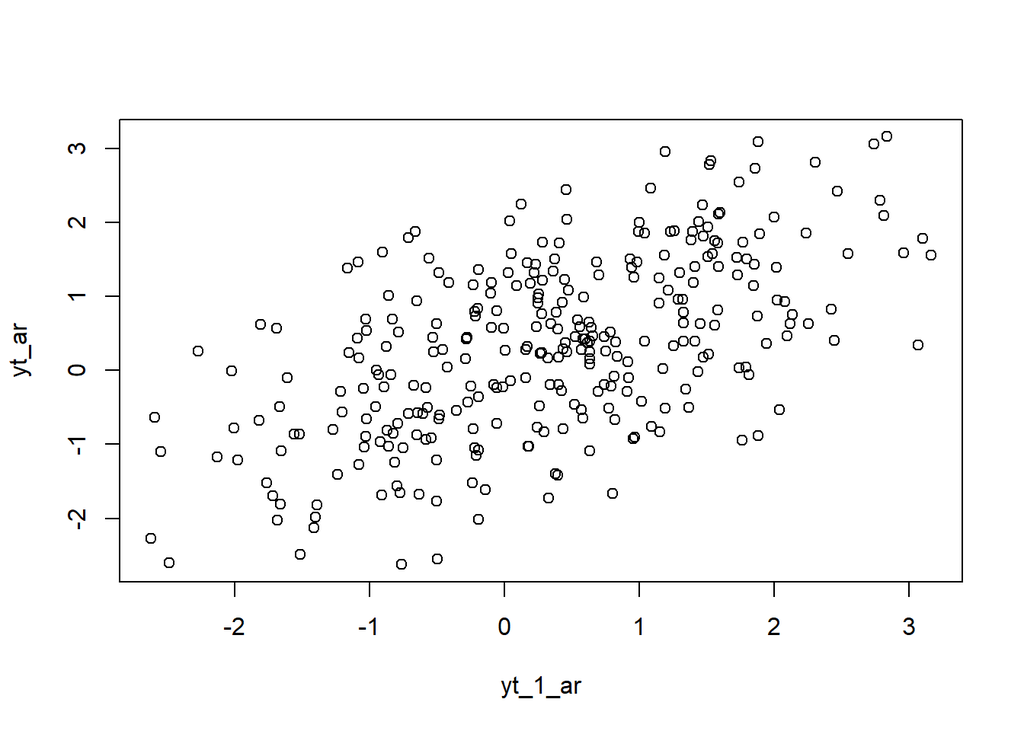

```r
plot(y=yt_ar,x=yt_1_ar)
```

Berdasarkan scatterplot tersebut, terlihat bahwa terdapat hubungan positif antara $Y_t$ dengan $Y_{t-1}$

```r
cor(yt_ar,yt_1_ar)
```

```
## [1] 0.5752916
```

#### Korelasi antara $Y_t$ dengan $Y_{t-2}$

```r
#Yt
yt_ar2 <- ar[-c(1,2)]
yt_ar2
```

```
##   [1]  2.075779615  0.931873163  1.511044750  0.221197275  1.325214116
##   [6]  0.391759302  0.558938197  0.595810624  0.430994228 -0.788659475
##  [11]  0.520394008 -0.459066120  0.279440151  1.216321189  1.086627559
##  [16] -0.754263971 -1.044462931 -1.031869407 -0.896969815 -0.221644050
##  [21] -1.048277945 -0.239746275 -1.517787083 -2.490621396 -2.598628661
##  [26] -0.637354210 -1.670135544 -0.489214306  1.325027859  0.792132280
##  [31] -0.210188516 -1.154255445  0.241280456 -0.766676873 -2.625137096
##  [36] -2.271725514  0.266427976  0.227491677  1.432083591 -0.014798462
##  [41] -0.223826918  0.798295655 -1.664916032 -1.812031579  0.624213758
##  [46]  0.656617596  0.463224073  2.040155248 -0.529030703  0.248592519
##  [51]  0.912425617  0.120327732  2.252606322  0.632442518  0.248455611
##  [56]  0.980033459  1.468204447  2.236121071  1.854059224  1.438164162
##  [61]  2.016098940  1.398803717  1.187397857  1.558709289  0.614156519
##  [66]  0.371093973  1.504939757  1.542846900  1.584270819  2.115341316
##  [71]  0.629512313  0.157618924 -0.095983835  1.193204045  2.958090923
```

[output cut: 45 more lines]

```r
#Yt-2
yt_2_ar <- ar[-c(299,300)]
yt_2_ar
```

```
##   [1]  1.000000000  2.000000000  2.075779615  0.931873163  1.511044750
##   [6]  0.221197275  1.325214116  0.391759302  0.558938197  0.595810624
##  [11]  0.430994228 -0.788659475  0.520394008 -0.459066120  0.279440151
##  [16]  1.216321189  1.086627559 -0.754263971 -1.044462931 -1.031869407
##  [21] -0.896969815 -0.221644050 -1.048277945 -0.239746275 -1.517787083
##  [26] -2.490621396 -2.598628661 -0.637354210 -1.670135544 -0.489214306
##  [31]  1.325027859  0.792132280 -0.210188516 -1.154255445  0.241280456
##  [36] -0.766676873 -2.625137096 -2.271725514  0.266427976  0.227491677
##  [41]  1.432083591 -0.014798462 -0.223826918  0.798295655 -1.664916032
##  [46] -1.812031579  0.624213758  0.656617596  0.463224073  2.040155248
##  [51] -0.529030703  0.248592519  0.912425617  0.120327732  2.252606322
##  [56]  0.632442518  0.248455611  0.980033459  1.468204447  2.236121071
##  [61]  1.854059224  1.438164162  2.016098940  1.398803717  1.187397857
##  [66]  1.558709289  0.614156519  0.371093973  1.504939757  1.542846900
##  [71]  1.584270819  2.115341316  0.629512313  0.157618924 -0.095983835
```

[output cut: 45 more lines]

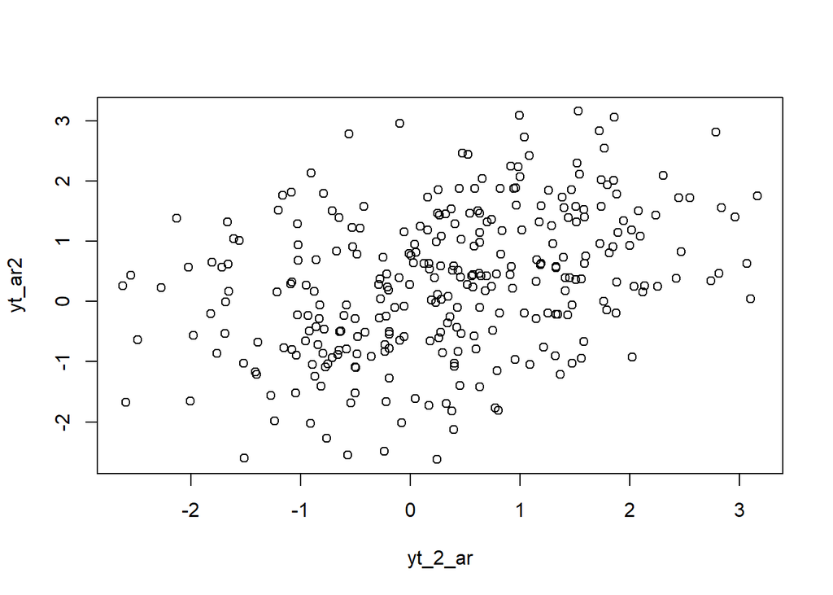

```r
plot(y=yt_ar2,x=yt_2_ar)
```

Berdasarkan scatterplot tersebut, terlihat bahwa terdapat hubungan positif antara $Y_t$ dengan $Y_{t-2}$.

```r
cor(yt_ar2,yt_2_ar)
```

```
## [1] 0.3667036
```

#### Korelasi antara $Y_t$ dengan $Y_{t-3}$

```r
#Yt
yt_ar3 <- ar[-c(1,2,3)]
yt_ar3
```

```
##   [1]  0.931873163  1.511044750  0.221197275  1.325214116  0.391759302
##   [6]  0.558938197  0.595810624  0.430994228 -0.788659475  0.520394008
##  [11] -0.459066120  0.279440151  1.216321189  1.086627559 -0.754263971
##  [16] -1.044462931 -1.031869407 -0.896969815 -0.221644050 -1.048277945
##  [21] -0.239746275 -1.517787083 -2.490621396 -2.598628661 -0.637354210
##  [26] -1.670135544 -0.489214306  1.325027859  0.792132280 -0.210188516
##  [31] -1.154255445  0.241280456 -0.766676873 -2.625137096 -2.271725514
##  [36]  0.266427976  0.227491677  1.432083591 -0.014798462 -0.223826918
##  [41]  0.798295655 -1.664916032 -1.812031579  0.624213758  0.656617596
##  [46]  0.463224073  2.040155248 -0.529030703  0.248592519  0.912425617
##  [51]  0.120327732  2.252606322  0.632442518  0.248455611  0.980033459
##  [56]  1.468204447  2.236121071  1.854059224  1.438164162  2.016098940
##  [61]  1.398803717  1.187397857  1.558709289  0.614156519  0.371093973
##  [66]  1.504939757  1.542846900  1.584270819  2.115341316  0.629512313
##  [71]  0.157618924 -0.095983835  1.193204045  2.958090923  1.586162842
```

[output cut: 45 more lines]

```r
#Yt-2
yt_3_ar <- ar[-c(298,299,300)]
yt_3_ar
```

```
##   [1]  1.000000000  2.000000000  2.075779615  0.931873163  1.511044750
##   [6]  0.221197275  1.325214116  0.391759302  0.558938197  0.595810624
##  [11]  0.430994228 -0.788659475  0.520394008 -0.459066120  0.279440151
##  [16]  1.216321189  1.086627559 -0.754263971 -1.044462931 -1.031869407
##  [21] -0.896969815 -0.221644050 -1.048277945 -0.239746275 -1.517787083
##  [26] -2.490621396 -2.598628661 -0.637354210 -1.670135544 -0.489214306
##  [31]  1.325027859  0.792132280 -0.210188516 -1.154255445  0.241280456
##  [36] -0.766676873 -2.625137096 -2.271725514  0.266427976  0.227491677
##  [41]  1.432083591 -0.014798462 -0.223826918  0.798295655 -1.664916032
##  [46] -1.812031579  0.624213758  0.656617596  0.463224073  2.040155248
##  [51] -0.529030703  0.248592519  0.912425617  0.120327732  2.252606322
##  [56]  0.632442518  0.248455611  0.980033459  1.468204447  2.236121071
##  [61]  1.854059224  1.438164162  2.016098940  1.398803717  1.187397857
##  [66]  1.558709289  0.614156519  0.371093973  1.504939757  1.542846900
##  [71]  1.584270819  2.115341316  0.629512313  0.157618924 -0.095983835
```

[output cut: 45 more lines]

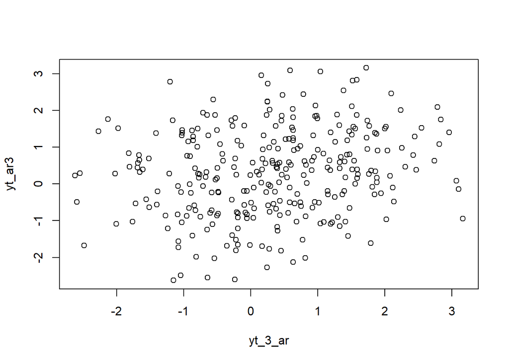

```r
plot(y=yt_ar3,x=yt_3_ar)
```

Berdasarkan scatterplot tersebut, terlihat bahwa terdapat hubungan positif antara $Y_t$ dengan $Y_{t-3}$.

```r
cor(yt_ar3,yt_3_ar)
```

```
## [1] 0.2041509
```

## Fungsi pembangkitan ARMA (2,2)

```r
set.seed(003)
wn <- rnorm(300)
```

### Cara Manual

```r
set.seed(003)
n = length(wn)
phi1 = 0.6
phi2 = 0.4
theta1 = 0.5
theta2 = 0.2

y.arma=c(2:n)
for (i in 3:n){y.arma[i] = phi1*y.arma[i-1] + theta1*wn[i-1]+wn[i]}
```

```r
#membuat fungsi dari model ARMA(2,2)
set.seed(003)
y.arma=c(1:300)
for (i in 3:300) {
  y.arma[i] <- 0.4 * y.arma[i-1] + 0.6 * y.arma[i-2] + wn[i] - 0.5 * wn[i-1] - 0.2 * wn[i-2]
}
```

```r
set.seed(003)
arma_sim <- arima.sim(list(order = c(2,0,2), ar=c(0.5,0.2) , ma=c(0.4,0.6)), n = 300)
```

## Karakteristik ARMA(2,2)

### Plot Time Series

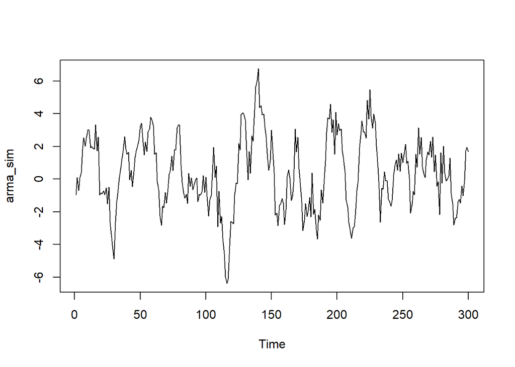

```r
ts.plot(arma_sim)
```

### Plot ACF

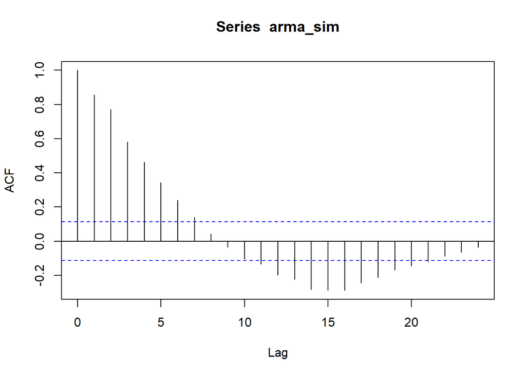

```r
acf(arma_sim)
```

Berdasarkan plot ACF tersebut terlihat bahwa plot ACF cenderung tails off dan cenderung membentuk pola grafik sinus

### Plot PACF

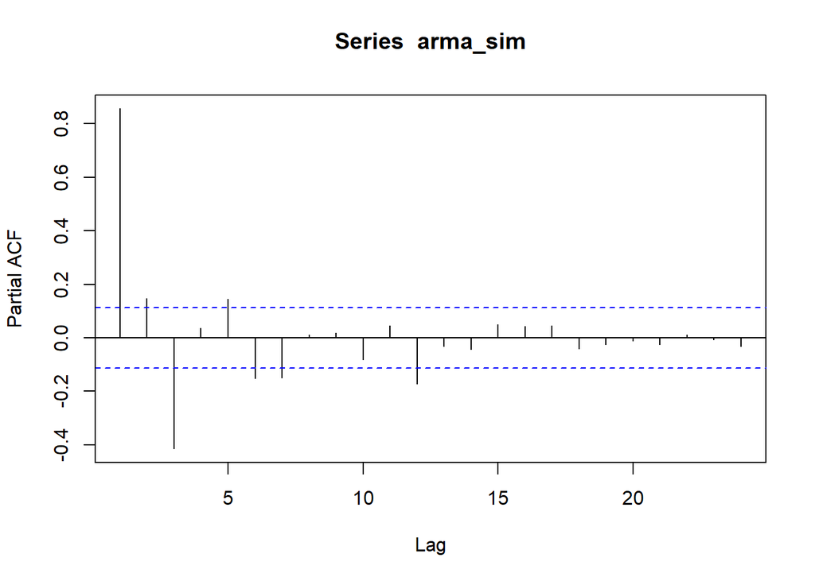

```r
pacf(arma_sim)
```

### Plot EACF

```r
TSA::eacf(arma_sim)
```

```
## AR/MA
##   0 1 2 3 4 5 6 7 8 9 10 11 12 13
## 0 x x x x x x x o o o x  x  x  x
## 1 x x o o o x o o o x o  x  o  x
## 2 x x x o o o o o o o o  o  o  x
## 3 o x x o x o o o o o o  o  o  o
## 4 x x x o o o o o o o o  o  o  o
## 5 x x x o o x o o o o o  o  o  o
## 6 x x x x o o o o o o o  o  o  o
## 7 o x x o o o o o o o x  o  o  o
```

## Scatterplot Antar Peubah Lag

### Korelasi antara $Y_t$ dengan $Y_{t-1}$

```r
#Yt
yt_arma22 <- arma_sim[-1]
yt_arma22
```

```
##   [1]  0.107233448 -0.694242723  0.076990053  0.429597442  1.838994922
##   [6]  2.544067433  2.018933047  2.524844964  3.037495515  3.005421268
##  [11]  1.926441566  1.989303968  1.896381400  1.826447850  3.339103921
##  [16]  1.733523882  2.584513865 -0.963820503 -0.824310557 -0.898177144
##  [21] -0.714473830 -0.939738055 -0.518919004 -1.505612243 -0.477177826
##  [26] -2.655805567 -3.369417899 -4.276349570 -4.875825213 -2.617366873
##  [31] -1.442829350 -0.845761780  0.098488591  0.556610120  1.265679438
##  [36]  1.749560933  2.596812697  1.848387036  1.536990200  1.637245596
##  [41] -0.032238485  0.554992347 -0.459202019  0.447683029  1.324242408
##  [46]  1.708953718  2.072613429  2.378835435  3.259141561  3.424079096
##  [51]  2.259399483  1.492456529  2.278070520  1.685330601  2.887321256
##  [56]  3.069209878  3.809311958  3.564457735  3.237258717  1.528875970
##  [61]  1.628554900 -0.122311241 -0.679962820 -2.227799221 -2.809058716
##  [66] -1.650490235 -1.746882872 -0.798109094 -1.473243308 -0.582507366
##  [71]  0.284865447  0.513855854  1.406522309  0.522330225  1.803952361
```

[output cut: 45 more lines]

```r
#Yt-1
yt_1_arma22 <- arma_sim[-300]
yt_1_arma22
```

```
##   [1] -0.947430170  0.107233448 -0.694242723  0.076990053  0.429597442
##   [6]  1.838994922  2.544067433  2.018933047  2.524844964  3.037495515
##  [11]  3.005421268  1.926441566  1.989303968  1.896381400  1.826447850
##  [16]  3.339103921  1.733523882  2.584513865 -0.963820503 -0.824310557
##  [21] -0.898177144 -0.714473830 -0.939738055 -0.518919004 -1.505612243
##  [26] -0.477177826 -2.655805567 -3.369417899 -4.276349570 -4.875825213
##  [31] -2.617366873 -1.442829350 -0.845761780  0.098488591  0.556610120
##  [36]  1.265679438  1.749560933  2.596812697  1.848387036  1.536990200
##  [41]  1.637245596 -0.032238485  0.554992347 -0.459202019  0.447683029
##  [46]  1.324242408  1.708953718  2.072613429  2.378835435  3.259141561
##  [51]  3.424079096  2.259399483  1.492456529  2.278070520  1.685330601
##  [56]  2.887321256  3.069209878  3.809311958  3.564457735  3.237258717
##  [61]  1.528875970  1.628554900 -0.122311241 -0.679962820 -2.227799221
##  [66] -2.809058716 -1.650490235 -1.746882872 -0.798109094 -1.473243308
##  [71] -0.582507366  0.284865447  0.513855854  1.406522309  0.522330225
```

[output cut: 45 more lines]

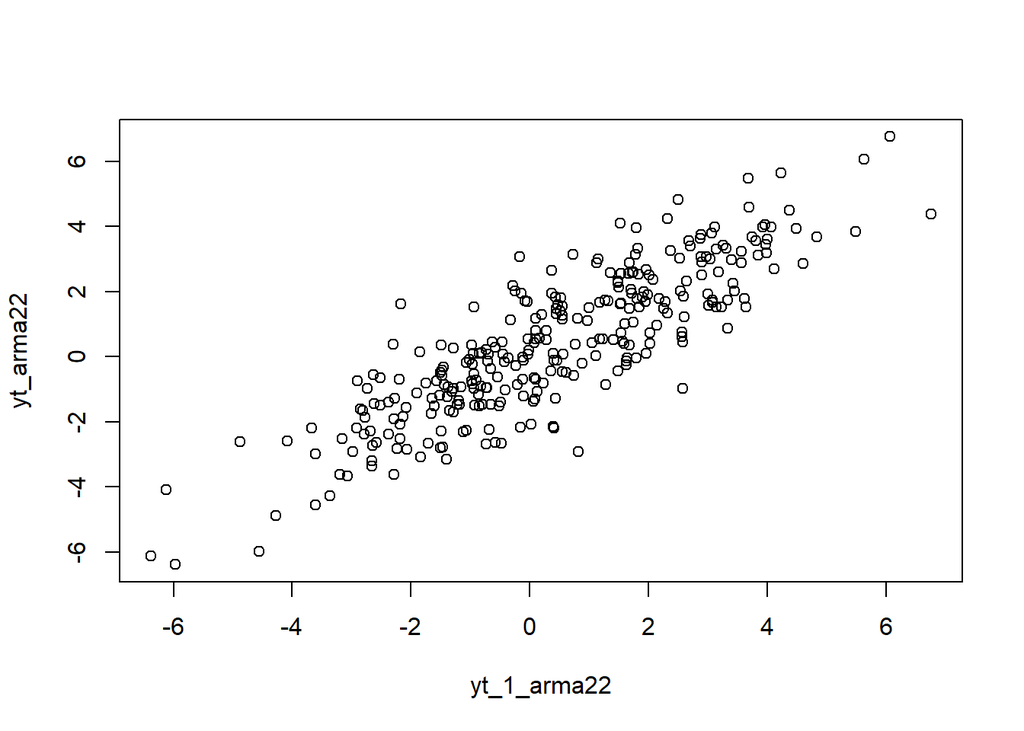

```r
plot(y=yt_arma22,x=yt_1_arma22)
```

Berdasarkan scatterplot tersebut, terlihat bahwa terdapat hubungan positif antara $Y_t$ dengan $Y_{t-1}$. Hal ini sesuai dengan teori yang ada

```r
cor(yt_arma22,yt_1_arma22)
```

```
## [1] 0.8575641
```

### Korelasi antara $Y_t$ dengan $Y_{t-2}$

```r
#Yt
yt_arma22.2 <- arma_sim[-c(1,2)]
yt_arma22.2
```

```
##   [1] -0.694242723  0.076990053  0.429597442  1.838994922  2.544067433
##   [6]  2.018933047  2.524844964  3.037495515  3.005421268  1.926441566
##  [11]  1.989303968  1.896381400  1.826447850  3.339103921  1.733523882
##  [16]  2.584513865 -0.963820503 -0.824310557 -0.898177144 -0.714473830
##  [21] -0.939738055 -0.518919004 -1.505612243 -0.477177826 -2.655805567
##  [26] -3.369417899 -4.276349570 -4.875825213 -2.617366873 -1.442829350
##  [31] -0.845761780  0.098488591  0.556610120  1.265679438  1.749560933
##  [36]  2.596812697  1.848387036  1.536990200  1.637245596 -0.032238485
##  [41]  0.554992347 -0.459202019  0.447683029  1.324242408  1.708953718
##  [46]  2.072613429  2.378835435  3.259141561  3.424079096  2.259399483
##  [51]  1.492456529  2.278070520  1.685330601  2.887321256  3.069209878
##  [56]  3.809311958  3.564457735  3.237258717  1.528875970  1.628554900
##  [61] -0.122311241 -0.679962820 -2.227799221 -2.809058716 -1.650490235
##  [66] -1.746882872 -0.798109094 -1.473243308 -0.582507366  0.284865447
##  [71]  0.513855854  1.406522309  0.522330225  1.803952361  1.786921469
```

[output cut: 45 more lines]

```r
#Yt-2
yt_2_arma22 <- arma_sim[-c(299,300)]
yt_2_arma22
```

```
##   [1] -0.947430170  0.107233448 -0.694242723  0.076990053  0.429597442
##   [6]  1.838994922  2.544067433  2.018933047  2.524844964  3.037495515
##  [11]  3.005421268  1.926441566  1.989303968  1.896381400  1.826447850
##  [16]  3.339103921  1.733523882  2.584513865 -0.963820503 -0.824310557
##  [21] -0.898177144 -0.714473830 -0.939738055 -0.518919004 -1.505612243
##  [26] -0.477177826 -2.655805567 -3.369417899 -4.276349570 -4.875825213
##  [31] -2.617366873 -1.442829350 -0.845761780  0.098488591  0.556610120
##  [36]  1.265679438  1.749560933  2.596812697  1.848387036  1.536990200
##  [41]  1.637245596 -0.032238485  0.554992347 -0.459202019  0.447683029
##  [46]  1.324242408  1.708953718  2.072613429  2.378835435  3.259141561
##  [51]  3.424079096  2.259399483  1.492456529  2.278070520  1.685330601
##  [56]  2.887321256  3.069209878  3.809311958  3.564457735  3.237258717
##  [61]  1.528875970  1.628554900 -0.122311241 -0.679962820 -2.227799221
##  [66] -2.809058716 -1.650490235 -1.746882872 -0.798109094 -1.473243308
##  [71] -0.582507366  0.284865447  0.513855854  1.406522309  0.522330225
```

[output cut: 45 more lines]

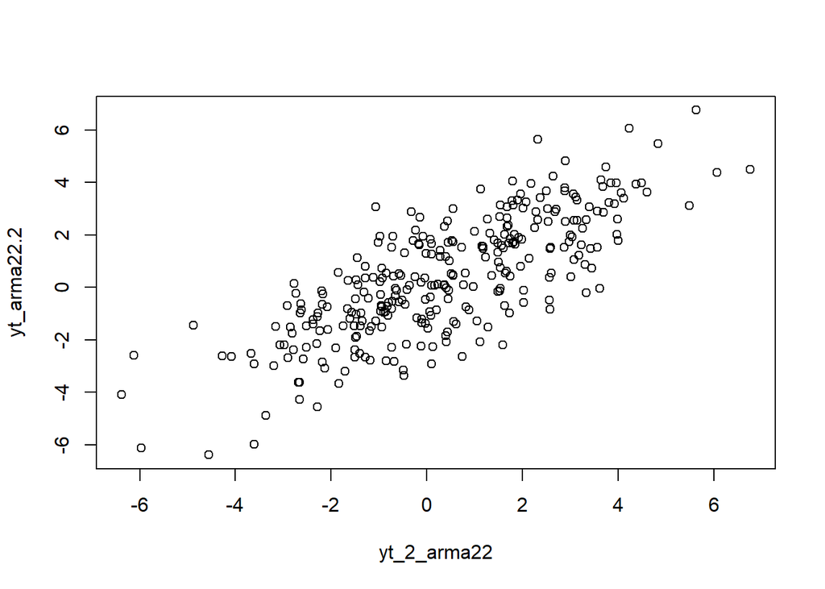

```r
plot(y=yt_arma22.2,x=yt_2_arma22)
```

Berdasarkan scatterplot tersebut, terlihat bahwa terdapat hubungan positif antara $Y_t$ dengan $Y_{t-2}$. Hal ini sesuai dengan teori yang ada

```r
cor(yt_arma22.2,yt_2_arma22)
```

```
## [1] 0.7742601
```

### Korelasi antara $Y_t$ dengan $Y_{t-3}$

```r
#Yt
yt_arma22.3 <- arma_sim[-c(1,2,3)]
yt_arma22.3
```

```
##   [1]  0.076990053  0.429597442  1.838994922  2.544067433  2.018933047
##   [6]  2.524844964  3.037495515  3.005421268  1.926441566  1.989303968
##  [11]  1.896381400  1.826447850  3.339103921  1.733523882  2.584513865
##  [16] -0.963820503 -0.824310557 -0.898177144 -0.714473830 -0.939738055
##  [21] -0.518919004 -1.505612243 -0.477177826 -2.655805567 -3.369417899
##  [26] -4.276349570 -4.875825213 -2.617366873 -1.442829350 -0.845761780
##  [31]  0.098488591  0.556610120  1.265679438  1.749560933  2.596812697
##  [36]  1.848387036  1.536990200  1.637245596 -0.032238485  0.554992347
##  [41] -0.459202019  0.447683029  1.324242408  1.708953718  2.072613429
##  [46]  2.378835435  3.259141561  3.424079096  2.259399483  1.492456529
##  [51]  2.278070520  1.685330601  2.887321256  3.069209878  3.809311958
##  [56]  3.564457735  3.237258717  1.528875970  1.628554900 -0.122311241
##  [61] -0.679962820 -2.227799221 -2.809058716 -1.650490235 -1.746882872
##  [66] -0.798109094 -1.473243308 -0.582507366  0.284865447  0.513855854
##  [71]  1.406522309  0.522330225  1.803952361  1.786921469  3.144488340
```

[output cut: 45 more lines]

```r
#Yt-2
yt_3_arma22 <- arma_sim[-c(289,299,300)]
yt_3_arma22
```

```
##   [1] -0.947430170  0.107233448 -0.694242723  0.076990053  0.429597442
##   [6]  1.838994922  2.544067433  2.018933047  2.524844964  3.037495515
##  [11]  3.005421268  1.926441566  1.989303968  1.896381400  1.826447850
##  [16]  3.339103921  1.733523882  2.584513865 -0.963820503 -0.824310557
##  [21] -0.898177144 -0.714473830 -0.939738055 -0.518919004 -1.505612243
##  [26] -0.477177826 -2.655805567 -3.369417899 -4.276349570 -4.875825213
##  [31] -2.617366873 -1.442829350 -0.845761780  0.098488591  0.556610120
##  [36]  1.265679438  1.749560933  2.596812697  1.848387036  1.536990200
##  [41]  1.637245596 -0.032238485  0.554992347 -0.459202019  0.447683029
##  [46]  1.324242408  1.708953718  2.072613429  2.378835435  3.259141561
##  [51]  3.424079096  2.259399483  1.492456529  2.278070520  1.685330601
##  [56]  2.887321256  3.069209878  3.809311958  3.564457735  3.237258717
##  [61]  1.528875970  1.628554900 -0.122311241 -0.679962820 -2.227799221
##  [66] -2.809058716 -1.650490235 -1.746882872 -0.798109094 -1.473243308
##  [71] -0.582507366  0.284865447  0.513855854  1.406522309  0.522330225
```

[output cut: 45 more lines]

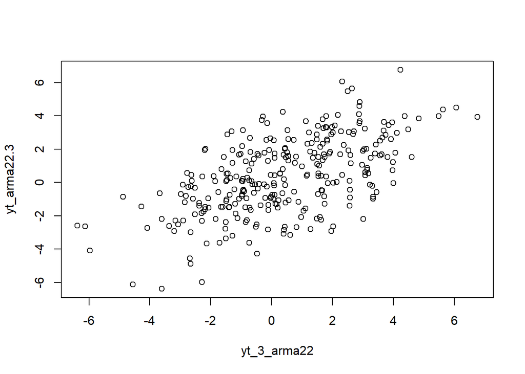

```r
plot(y=yt_arma22.3,x=yt_3_arma22)
```

Berdasarkan scatterplot tersebut, terlihat bahwa terdapat hubungan positif antara $Y_t$ dengan $Y_{t-3}$. Hal ini sesuai dengan teori yang ada

```r
cor(yt_arma22.3,yt_3_arma22)
```

```
## [1] 0.5858728
```

### Perbandingan korelasi $Yt_t$ dengan $Y_{t-1}$, $Yt_t$ dengan $Y_{t-2}$, & $Yt_t$ dengan $Y_{t-3}$

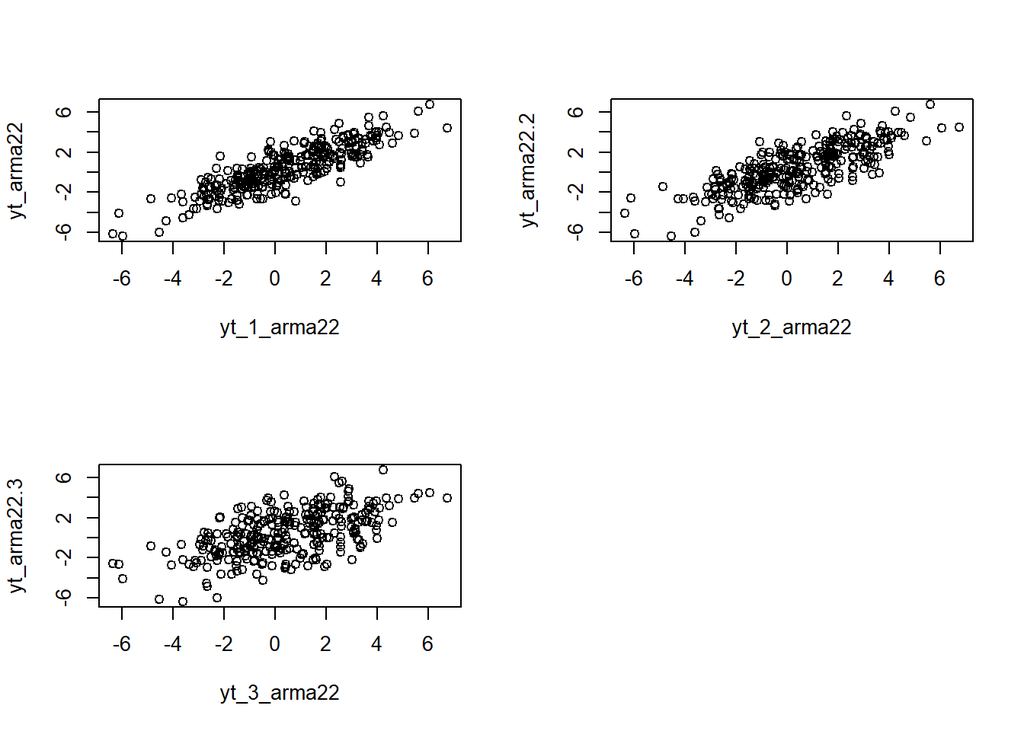

```r
par(mfrow=c(2,2))
plot(y=yt_arma22,x=yt_1_arma22)
plot(y=yt_arma22.2,x=yt_2_arma22)
plot(y=yt_arma22.3,x=yt_3_arma22)
```